# Introduction

This report explores deeper the '2014 Mental Health in Tech' survey data, which uses self-reported responses from individuals from various backgrounds. Its goals is to identify and highlight the mental health of individuals that may need help, here I created a predictive model that determines whether or not a survey taker has sought mental health treatment.

**The analysis is conducted using the following tools and libraries**:

- Python 3.12 for development and scripting (Any version that supports these libraries should work fine)
- `Pandas` for data manipulation and preprocessing
- `NumPy` for numerical operations
- `Matplotlib` & `Seaborn` for visualizations
- `Scikit-learn` for model building, transformation pipelines, and evaluation

**The workflow follows these major steps**:

- **Data Cleaning**: Handling inconsistent gender values, outlier ages, and missing data
- **Feature Engineering**: Binning age groups and one-hot encoding categorical variables
- **Model Construction**: Using a pipeline to preprocess features and train a RandomForestClassifier
- **Bias Analysis**: Evaluating feature importance and subgroup-level accuracy (e.g., gender, age)
- **Reflection**: Interpreting how bias in the dataset influences predictions

# Data Overview and Cleaning

```python
# Import libraries
import pandas as pd
from sklearn.model_selection import train_test_split
from sklearn.compose import ColumnTransformer
from sklearn.preprocessing import OneHotEncoder
from sklearn.pipeline import Pipeline
from sklearn.ensemble import RandomForestClassifier
from sklearn.metrics import classification_report, confusion_matrix, ConfusionMatrixDisplay
import matplotlib.pyplot as plt

# Load dataset and check if valid
df = pd.read_csv('./data/survey.csv')
df.head()
```

|  | Timestamp | Age | Gender | Country | state | self_employed | family_history | treatment | work_interfere | no_employees | ... | leave | mental_health_consequence | phys_health_consequence | coworkers | supervisor | mental_health_interview | phys_health_interview | mental_vs_physical | obs_consequence | comments |
| --- | --- | --- | --- | --- | --- | --- | --- | --- | --- | --- | --- | --- | --- | --- | --- | --- | --- | --- | --- | --- | --- |
| 0 | 2014-08-27 11:29:31 | 37 | Female | United States | IL | NaN | No | Yes | Often | 6-25 | ... | Somewhat easy | No | No | Some of them | Yes | No | Maybe | Yes | No | NaN |
| 1 | 2014-08-27 11:29:37 | 44 | M | United States | IN | NaN | No | No | Rarely | More than 1000 | ... | Don't know | Maybe | No | No | No | No | No | Don't know | No | NaN |
| 2 | 2014-08-27 11:29:44 | 32 | Male | Canada | NaN | NaN | No | No | Rarely | 6-25 | ... | Somewhat difficult | No | No | Yes | Yes | Yes | Yes | No | No | NaN |
| 3 | 2014-08-27 11:29:46 | 31 | Male | United Kingdom | NaN | NaN | Yes | Yes | Often | 26-100 | ... | Somewhat difficult | Yes | Yes | Some of them | No | Maybe | Maybe | No | Yes | NaN |
| 4 | 2014-08-27 11:30:22 | 31 | Male | United States | TX | NaN | No | No | Never | 100-500 | ... | Don't know | No | No | Some of them | Yes | Yes | Yes | Don't know | No | NaN |

5 rows × 27 columns

```python
# Drop unnecessary columns
df_clean = df.drop(columns=["Timestamp", "comments", "state"])

# Fill missing values
df_clean['self_employed'] = df_clean['self_employed'].fillna('Unknown')
df_clean['work_interfere'] = df_clean['work_interfere'].fillna('Unknown')
```

```python
def normalize_gender(g):
    g = str(g).strip().lower()
    if g in ['male', 'm', 'cis male', 'man']:
        return 'Male'
    elif g in ['female', 'f', 'cis female', 'woman', 'female (cis)']:
        return 'Female'
    else:
        return 'Nonbinary/Other'

# Normalize Gender
df_clean['normalized_gender'] = df_clean['Gender'].apply(normalize_gender)

# Normalize Age
df_clean = df_clean[(df_clean['Age'] > 17) & (df_clean['Age'] <= 80)]
```

```python
# Define categorical columns
categorical_cols = [
    'normalized_gender', 'self_employed', 'work_interfere', 'no_employees',
    'remote_work', 'tech_company', 'benefits', 'care_options', 'wellness_program',
    'seek_help', 'anonymity', 'leave', 'mental_health_consequence',
    'phys_health_consequence', 'coworkers', 'supervisor',
    'mental_vs_physical', 'obs_consequence', 'Country'
]

# Fill remaining categorical NAs
df_clean[categorical_cols] = df_clean[categorical_cols].fillna('Unknown')

# Split into X and y
X = df_clean[categorical_cols + ['Age']]
y = df_clean['treatment'].map({'Yes': 1, 'No': 0})

# Train/test split
X_train, X_test, y_train, y_test = train_test_split(
    X, y, stratify=y, test_size=0.2, random_state=42
)
```

# Build Model

```python
# Build transformer and pipeline
preprocessor = ColumnTransformer(
    transformers=[
        ('cat', OneHotEncoder(drop='first', handle_unknown='ignore'), categorical_cols)
    ],
    remainder='passthrough'
)

pipeline = Pipeline(steps=[
    ('preprocessor', preprocessor),
    ('classifier', RandomForestClassifier(random_state=42))
])

# Fit model
pipeline.fit(X_train, y_train)
```

```
Pipeline(steps=[('preprocessor',
                 ColumnTransformer(remainder='passthrough',
                                   transformers=[('cat',
                                                  OneHotEncoder(drop='first',
                                                                handle_unknown='ignore'),
                                                  ['normalized_gender',
                                                   'self_employed',
                                                   'work_interfere',
                                                   'no_employees',
                                                   'remote_work',
                                                   'tech_company', 'benefits',
                                                   'care_options',
                                                   'wellness_program',
                                                   'seek_help', 'anonymity',
                                                   'leave',
                                                   'mental_health_consequence',
                                                   'phys_health_consequence',
                                                   'coworkers', 'supervisor',
                                                   'mental_vs_physical',
                                                   'obs_consequence',
                                                   'Country'])])),
                ('classifier', RandomForestClassifier(random_state=42))])
```

# Model Eval

```
Classification Report:
              precision    recall  f1-score   support

           0       0.84      0.74      0.79       124
           1       0.77      0.87      0.82       127

    accuracy                           0.80       251
   macro avg       0.81      0.80      0.80       251
weighted avg       0.81      0.80      0.80       251
```

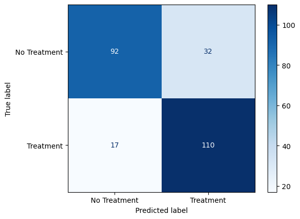

```python
# Predict and evaluate
y_pred = pipeline.predict(X_test)

print("Classification Report:")
print(classification_report(y_test, y_pred))

disp = ConfusionMatrixDisplay(confusion_matrix(y_test, y_pred),
                              display_labels=['No Treatment', 'Treatment'])
disp.plot(cmap='Blues')
plt.show()
```

## Feature Importance

```python
importance_df = pd.DataFrame({
    'feature': all_feature_names,
    'importance': importances
}).sort_values(by='importance', ascending=False)

biased_keywords = ['gender', 'Country', 'Age', 'self_employed']
biased_features = importance_df[importance_df['feature'].str.contains('|'.join(biased_keywords), case=False)]

biased_features.sort_values(by='importance', ascending=False)
```

[output not shown]

|  | feature | importance |
| --- | --- | --- |
| 83 | Age | 0.078187 |
| 0 | normalized_gender_Male | 0.021878 |
| 82 | Country_United States | 0.018065 |
| 3 | self_employed_Yes | 0.012972 |
| 81 | Country_United Kingdom | 0.011925 |
| 45 | Country_Canada | 0.008419 |
| 59 | Country_Ireland | 0.006200 |
| 1 | normalized_gender_Nonbinary/Other | 0.004108 |
| 55 | Country_Germany | 0.003833 |
| 66 | Country_Netherlands | 0.002884 |
| 43 | Country_Brazil | 0.002694 |
| 2 | self_employed_Unknown | 0.002056 |
| 74 | Country_Singapore | 0.001633 |
| 58 | Country_India | 0.001621 |
| 47 | Country_Colombia | 0.001581 |
| 79 | Country_Switzerland | 0.001580 |
| 53 | Country_France | 0.001571 |
| 67 | Country_New Zealand | 0.001427 |
| 60 | Country_Israel | 0.001358 |
| 70 | Country_Poland | 0.001304 |
| 78 | Country_Sweden | 0.001203 |
| 61 | Country_Italy | 0.001149 |
| 73 | Country_Russia | 0.000927 |
| 50 | Country_Czech Republic | 0.000848 |
| 40 | Country_Austria | 0.000673 |
| 44 | Country_Bulgaria | 0.000666 |
| 41 | Country_Belgium | 0.000603 |
| 76 | Country_South Africa | 0.000454 |
| 46 | Country_China | 0.000428 |
| 52 | Country_Finland | 0.000407 |
| 54 | Country_Georgia | 0.000381 |
| 57 | Country_Hungary | 0.000361 |
| 75 | Country_Slovenia | 0.000311 |
| 42 | Country_Bosnia and Herzegovina | 0.000251 |
| 51 | Country_Denmark | 0.000192 |
| 48 | Country_Costa Rica | 0.000176 |
| 80 | Country_Thailand | 0.000165 |
| 49 | Country_Croatia | 0.000133 |
| 65 | Country_Moldova | 0.000111 |
| 56 | Country_Greece | 0.000110 |
| 62 | Country_Japan | 0.000069 |
| 63 | Country_Latvia | 0.000062 |
| 77 | Country_Spain | 0.000046 |
| 68 | Country_Nigeria | 0.000027 |
| 69 | Country_Norway | 0.000014 |
| 71 | Country_Portugal | 0.000007 |
| 72 | Country_Romania | 0.000001 |
| 64 | Country_Mexico | 0.000000 |

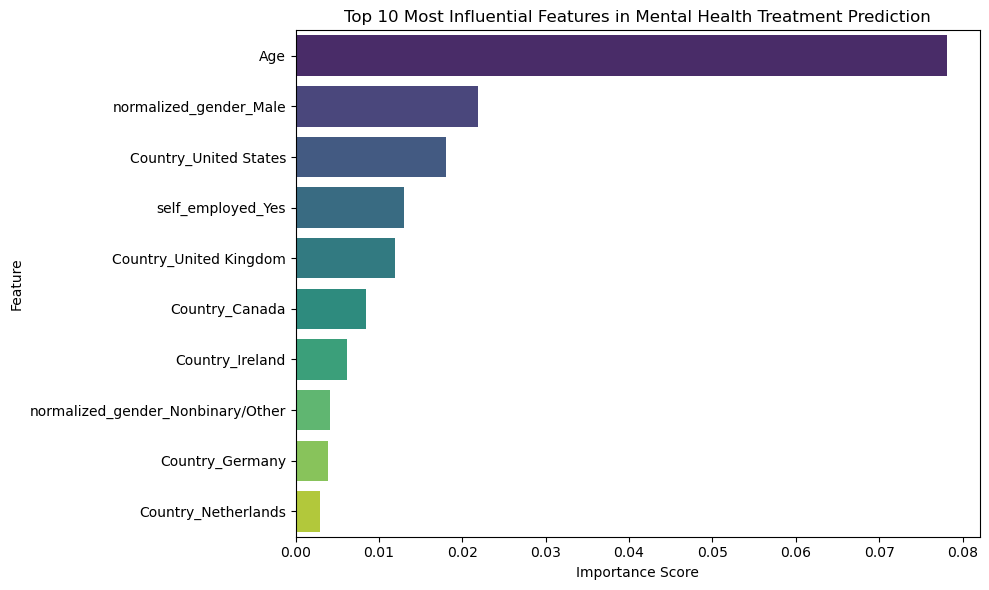

```python
import seaborn as sns

# Load the most recent cleaned dataset and feature importance
feature_importance_df = pd.DataFrame({
    'feature': [
        'Age', 'normalized_gender_Male', 'Country_United States',
        'self_employed_Yes', 'Country_United Kingdom', 'Country_Canada',
        'Country_Ireland', 'normalized_gender_Nonbinary/Other',
        'Country_Germany', 'Country_Netherlands'
    ],
    'importance': [
        0.078187, 0.021878, 0.018065,
        0.012972, 0.011925, 0.008419,
        0.006200, 0.004108, 0.003833, 0.002884
    ]
})

# Plot top 10 feature importances
plt.figure(figsize=(10, 6))
sns.barplot(data=feature_importance_df, x='importance', y='feature', palette='viridis')
plt.title('Top 10 Most Influential Features in Mental Health Treatment Prediction')
plt.xlabel('Importance Score')
plt.ylabel('Feature')
plt.tight_layout()
plt.show()
```

### Feature Importance & Implications

| Feature | Importance |
| --- | --- |
| Age | 0.0782 |
| normalized_gender_Male | 0.0219 |
| Country_United States | 0.0181 |
| self_employed_Yes | 0.0130 |
| Country_United Kingdom | 0.0119 |

### Fairness Reflection

These findings underscore that the model may not be learning *why* someone seeks treatment — but rather *who* is most likely to based on historically biased factors.

This may not be an issue for exploratory research, but if deployed in real-world scenarios, it could lead to **discriminatory outcomes** if predictions are used to allocate resources or interventions.

## Subgroup Accuracy

```python
from sklearn.metrics import accuracy_score

# Make predictions
y_pred = pipeline.predict(X_test)

# Copy test set to match with predictions
X_test_copy = X_test.copy()
X_test_copy['y_true'] = y_test
X_test_copy['y_pred'] = y_pred

# Restore demographic columns (normalized_gender + Age) from full df_clean
X_test_copy['normalized_gender'] = df_clean.loc[X_test_copy.index, 'normalized_gender']
X_test_copy['Age'] = df_clean.loc[X_test_copy.index, 'Age']

# Create age bins
bins = [18, 25, 35, 45, 60, 80]
labels = ['18–24', '25–34', '35–44', '45–59', '60+']
X_test_copy['age_group'] = pd.cut(X_test_copy['Age'], bins=bins, labels=labels, right=False)

# Accuracy by gender
gender_acc = X_test_copy.groupby('normalized_gender').apply(
    lambda g: accuracy_score(g['y_true'], g['y_pred'])
).reset_index(name='Accuracy')

# Accuracy by age group
age_acc = X_test_copy.groupby('age_group').apply(
    lambda g: accuracy_score(g['y_true'], g['y_pred'])
).reset_index(name='Accuracy')

print("Accuracy by Gender:")
print(gender_acc)

print("\nAccuracy by Age Group:")
print(age_acc)
```

```
Accuracy by Gender:
  normalized_gender  Accuracy
0            Female  0.916667
1              Male  0.780000
2   Nonbinary/Other  0.666667

Accuracy by Age Group:
  age_group  Accuracy
0     18–24  0.838710
1     25–34  0.835714
2     35–44  0.714286
3     45–59  0.812500
4       60+  1.000000
```

### 📉 Subgroup Accuracy Analysis

To better understand how bias in the dataset may affect model behavior, we evaluated accuracy across `normalized_gender` and `age_group` subgroups in the test set.

#### Gender-Based Accuracy

| Gender | Accuracy |
| --- | --- |
| Female | 91.7% |
| Male | 78.0% |
| Nonbinary/Other | 66.7% |

The model shows its highest accuracy for female respondents and lowest for nonbinary/other individuals. This performance gap suggests that underrepresented gender identities in the data may lead to less reliable predictions — a direct consequence of bias in the original dataset.

#### Age-Based Accuracy

| Age Group | Accuracy |
| --- | --- |
| 18–24 | 83.9% |
| 25–34 | 83.6% |
| 35–44 | 71.4% |
| 45–59 | 81.3% |
| 60+ | 100.0% |

While the model performs consistently well across younger and older age groups, the 35–44 range shows a noticeable drop in accuracy. The perfect accuracy for the 60+ group should be interpreted cautiously, as it may result from a small number of examples rather than meaningful generalization.

These results further reinforce that model performance is **not uniform** across demographic lines — an important observation when analyzing how biased datasets can yield discriminatory behavior in predictive systems.

# Conclusion

## Conclusion & Reflection on Bias in Predictive Modeling

This study set out with the hypothesis that demographic and cultural biases embedded in the '2014 Mental Health in Tech' survey dataset would manifest in machine learning predictions. The results confirm this.

### Ethical Implications

If this model were deployed in the real world — for example, as part of an HR mental health prediction tool — it could:

- Misclassify individuals from underrepresented countries or identities.
- Amplify existing cultural stigmas about mental health.
- Undermine trust in AI-based recommendations due to uneven treatment across groups.

### Final Thoughts

This report demonstrates that machine learning models can produce seemingly high-performing yet fundamentally skewed results. This analysis demonstrates the risks of encoding social and cultural disparities into machine learning predictions, especially in sensitive domains like mental health. Further work should explore strategies for mitigating such biases while preserving the predictive power of behavioral insights.